# Machine Learning Course Project

Olga Nevinchana

2026-04-14

# Introduction

## Background

Six young health participants were asked to perform one set of 10 repetitions of the Unilateral Dumbbell Biceps Curl in five different fashions: exactly according to the specification (Class A), throwing the elbows to the front (Class B), lifting the dumbbell only halfway (Class C), lowering the dumbbell only halfway (Class D) and throwing the hips to the front (Class E).

## Project goal

To predict the manner in which research participants did the exercise.

Loading data and libraries

# Data Cleaning

Comparing two datasets and checking for any unique variables

```r
setdiff(names(training), names(testing))
```

```
## [1] "classe"
```

```r
setdiff(names(testing), names(training))
```

```
## [1] "problem_id"
```

Checking for NA

```r
any(is.na(training))
```

```
## [1] TRUE
```

```r
any(is.na(testing))
```

```
## [1] TRUE
```

There are variables with NAs in both datasets.

Identifying NA variable in both training and testing datasets

```r
na_train <- names(which(colSums(is.na(training)) > 0))
na_test <- names(which(colSums(is.na(testing)) > 0))
```

Removing variables that contain non-meaningful predictors: IDs, problem IDs, “timestamp” in both training and testing datasets

```r
training_subset <- training[, !(names(training) %in% c("X", "user_name", "new_window", "num_window") | grepl("timestamp", names(training)))]
testing_subset <- testing[, !(names(testing) %in% c("X", "problem_id", "user_name", "new_window", "num_window") | grepl("timestamp", names(testing)))]
```

Checking the number of NA cases to decide if they can be imputed or must be excluded from the analysis

```r
summary(training_subset[na_train])
```

```
##  max_roll_belt     max_picth_belt  min_roll_belt     min_pitch_belt
##  Min.   :-94.300   Min.   : 3.00   Min.   :-180.00   Min.   : 0.00
##  1st Qu.:-88.000   1st Qu.: 5.00   1st Qu.: -88.40   1st Qu.: 3.00
##  Median : -5.100   Median :18.00   Median :  -7.85   Median :16.00
##  Mean   : -6.667   Mean   :12.92   Mean   : -10.44   Mean   :10.76
##  3rd Qu.: 18.500   3rd Qu.:19.00   3rd Qu.:   9.05   3rd Qu.:17.00
##  Max.   :180.000   Max.   :30.00   Max.   : 173.00   Max.   :23.00
##  NA's   :19216     NA's   :19216   NA's   :19216     NA's   :19216
##  amplitude_roll_belt amplitude_pitch_belt var_total_accel_belt avg_roll_belt
##  Min.   :  0.000     Min.   : 0.000       Min.   : 0.0000      Min.   :-27.40
##  1st Qu.:  0.300     1st Qu.: 1.000       1st Qu.: 0.1000      1st Qu.:  1.10
##  Median :  1.000     Median : 1.000       Median : 0.2000      Median :116.35
##  Mean   :  3.769     Mean   : 2.167       Mean   : 0.9262      Mean   : 68.06
##  3rd Qu.:  2.083     3rd Qu.: 2.000       3rd Qu.: 0.3000      3rd Qu.:123.38
##  Max.   :360.000     Max.   :12.000       Max.   :16.5000      Max.   :157.40
##  NA's   :19216       NA's   :19216        NA's   :19216        NA's   :19216
##  stddev_roll_belt var_roll_belt     avg_pitch_belt     stddev_pitch_belt
##  Min.   : 0.000   Min.   :  0.000   Min.   :-51.4000   Min.   :0.0000
##  1st Qu.: 0.200   1st Qu.:  0.000   1st Qu.:  2.0250   1st Qu.:0.2000
##  Median : 0.400   Median :  0.100   Median :  5.2000   Median :0.4000
##  Mean   : 1.337   Mean   :  7.699   Mean   :  0.5195   Mean   :0.6027
##  3rd Qu.: 0.700   3rd Qu.:  0.500   3rd Qu.: 15.7750   3rd Qu.:0.7000
##  Max.   :14.200   Max.   :200.700   Max.   : 59.7000   Max.   :4.0000
##  NA's   :19216    NA's   :19216     NA's   :19216      NA's   :19216
##  var_pitch_belt     avg_yaw_belt      stddev_yaw_belt    var_yaw_belt
##  Min.   : 0.0000   Min.   :-138.300   Min.   :  0.000   Min.   :    0.000
##  1st Qu.: 0.0000   1st Qu.: -88.175   1st Qu.:  0.100   1st Qu.:    0.010
##  Median : 0.1000   Median :  -6.550   Median :  0.300   Median :    0.090
##  Mean   : 0.7657   Mean   :  -8.831   Mean   :  1.341   Mean   :  107.487
##  3rd Qu.: 0.5000   3rd Qu.:  14.125   3rd Qu.:  0.700   3rd Qu.:    0.475
##  Max.   :16.2000   Max.   : 173.500   Max.   :176.600   Max.   :31183.240
##  NA's   :19216     NA's   :19216      NA's   :19216     NA's   :19216
##  var_accel_arm     avg_roll_arm     stddev_roll_arm    var_roll_arm
##  Min.   :  0.00   Min.   :-166.67   Min.   :  0.000   Min.   :    0.000
##  1st Qu.:  9.03   1st Qu.: -38.37   1st Qu.:  1.376   1st Qu.:    1.898
##  Median : 40.61   Median :   0.00   Median :  5.702   Median :   32.517
##  Mean   : 53.24   Mean   :  12.68   Mean   : 11.201   Mean   :  417.264
##  3rd Qu.: 75.62   3rd Qu.:  76.32   3rd Qu.: 14.921   3rd Qu.:  222.647
##  Max.   :331.70   Max.   : 163.33   Max.   :161.964   Max.   :26232.208
##  NA's   :19216    NA's   :19216     NA's   :19216     NA's   :19216
```

[output cut: 89 more lines]

```
##  Min.   :  0.0000    Min.   :    0.000   Min.   :-68.17    Min.   : 0.0000
##  1st Qu.:  0.4283    1st Qu.:    0.183   1st Qu.:  0.00    1st Qu.: 0.3364
##  Median :  8.0295    Median :   64.478   Median : 12.02    Median : 5.5158
##  Mean   : 41.9860    Mean   : 5274.095   Mean   : 11.79    Mean   : 7.9773
##  3rd Qu.: 85.3730    3rd Qu.: 7289.084   3rd Qu.: 28.48    3rd Qu.:12.8659
##  Max.   :179.1710    Max.   :32102.237   Max.   : 72.09    Max.   :47.7453
##  NA's   :19216       NA's   :19216       NA's   :19216     NA's   :19216
##  var_pitch_forearm   avg_yaw_forearm   stddev_yaw_forearm var_yaw_forearm
##  Min.   :   0.0000   Min.   :-155.06   Min.   :  0.0000   Min.   :    0.000
##  1st Qu.:   0.1132   1st Qu.: -26.26   1st Qu.:  0.5239   1st Qu.:    0.275
##  Median :  30.4251   Median :   0.00   Median : 24.7427   Median :  612.214
##  Mean   : 139.5933   Mean   :  18.00   Mean   : 44.8544   Mean   : 4639.849
##  3rd Qu.: 165.5321   3rd Qu.:  85.79   3rd Qu.: 85.8166   3rd Qu.: 7368.414
##  Max.   :2279.6168   Max.   : 169.24   Max.   :197.5078   Max.   :39009.333
##  NA's   :19216       NA's   :19216     NA's   :19216      NA's   :19216
```

```r
summary(testing_subset[na_test])
```

```
##  kurtosis_roll_belt kurtosis_picth_belt kurtosis_yaw_belt skewness_roll_belt
##  Mode:logical       Mode:logical        Mode:logical      Mode:logical
##  NA's:20            NA's:20             NA's:20           NA's:20
##  skewness_roll_belt.1 skewness_yaw_belt max_roll_belt  max_picth_belt
##  Mode:logical         Mode:logical      Mode:logical   Mode:logical
##  NA's:20              NA's:20           NA's:20        NA's:20
##  max_yaw_belt   min_roll_belt  min_pitch_belt min_yaw_belt
##  Mode:logical   Mode:logical   Mode:logical   Mode:logical
##  NA's:20        NA's:20        NA's:20        NA's:20
##  amplitude_roll_belt amplitude_pitch_belt amplitude_yaw_belt
##  Mode:logical        Mode:logical         Mode:logical
##  NA's:20             NA's:20              NA's:20
##  var_total_accel_belt avg_roll_belt  stddev_roll_belt var_roll_belt
##  Mode:logical         Mode:logical   Mode:logical     Mode:logical
##  NA's:20              NA's:20        NA's:20          NA's:20
##  avg_pitch_belt stddev_pitch_belt var_pitch_belt avg_yaw_belt   stddev_yaw_belt
##  Mode:logical   Mode:logical      Mode:logical   Mode:logical   Mode:logical
##  NA's:20        NA's:20           NA's:20        NA's:20        NA's:20
##  var_yaw_belt   var_accel_arm  avg_roll_arm   stddev_roll_arm var_roll_arm
##  Mode:logical   Mode:logical   Mode:logical   Mode:logical    Mode:logical
##  NA's:20        NA's:20        NA's:20        NA's:20         NA's:20
##  avg_pitch_arm  stddev_pitch_arm var_pitch_arm  avg_yaw_arm    stddev_yaw_arm
##  Mode:logical   Mode:logical     Mode:logical   Mode:logical   Mode:logical
##  NA's:20        NA's:20          NA's:20        NA's:20        NA's:20
##  var_yaw_arm    kurtosis_roll_arm kurtosis_picth_arm kurtosis_yaw_arm
##  Mode:logical   Mode:logical      Mode:logical       Mode:logical
##  NA's:20        NA's:20           NA's:20            NA's:20
##  skewness_roll_arm skewness_pitch_arm skewness_yaw_arm max_roll_arm
##  Mode:logical      Mode:logical       Mode:logical     Mode:logical
##  NA's:20           NA's:20            NA's:20          NA's:20
##  max_picth_arm  max_yaw_arm    min_roll_arm   min_pitch_arm  min_yaw_arm
##  Mode:logical   Mode:logical   Mode:logical   Mode:logical   Mode:logical
##  NA's:20        NA's:20        NA's:20        NA's:20        NA's:20
##  amplitude_roll_arm amplitude_pitch_arm amplitude_yaw_arm
##  Mode:logical       Mode:logical        Mode:logical
##  NA's:20            NA's:20             NA's:20
##  kurtosis_roll_dumbbell kurtosis_picth_dumbbell kurtosis_yaw_dumbbell
##  Mode:logical           Mode:logical            Mode:logical
##  NA's:20                NA's:20                 NA's:20
##  skewness_roll_dumbbell skewness_pitch_dumbbell skewness_yaw_dumbbell
```

[output cut: 26 more lines]

```
##  min_roll_forearm min_pitch_forearm min_yaw_forearm amplitude_roll_forearm
##  Mode:logical     Mode:logical      Mode:logical    Mode:logical
##  NA's:20          NA's:20           NA's:20         NA's:20
##  amplitude_pitch_forearm amplitude_yaw_forearm var_accel_forearm
##  Mode:logical            Mode:logical          Mode:logical
##  NA's:20                 NA's:20               NA's:20
##  avg_roll_forearm stddev_roll_forearm var_roll_forearm avg_pitch_forearm
##  Mode:logical     Mode:logical        Mode:logical     Mode:logical
##  NA's:20          NA's:20             NA's:20          NA's:20
##  stddev_pitch_forearm var_pitch_forearm avg_yaw_forearm stddev_yaw_forearm
##  Mode:logical         Mode:logical      Mode:logical    Mode:logical
##  NA's:20              NA's:20           NA's:20         NA's:20
##  var_yaw_forearm
##  Mode:logical
##  NA's:20
```

There are variable that contain 97% of NAs in na_train and 100% NAs in na_test - all to be excluded

Subset both training and testing datasets, excluding variables that don’t contain any values in the testing dataset

```r
training_subset <- training_subset[, !(names(training_subset) %in% na_test)]
testing_subset <- testing_subset[, !(names(testing_subset) %in% na_test)]
```

Checking for NA in both datasets

```r
any(is.na(training_subset))
```

```
## [1] FALSE
```

```r
any(is.na(testing_subset))
```

```
## [1] FALSE
```

Variables with missing values have been excluded from both training and testing datasets.

# Data Analysis

Splitting the training dataset into training and testing.

```r
set.seed(111)
inTrain = createDataPartition(training_subset$classe, p = 3/4)[[1]]
training_data = training_subset[ inTrain,]
testing_data = training_subset[-inTrain,]
```

Selecting predictors

Creating inputs for model LASSO

```r
x_train <- model.matrix(classe~., data=training_data)[,-1]
y_train <- as.factor(training_data$classe)

x_test <- model.matrix(classe~., data=testing_data)[,-1]
y_test <- as.factor(testing_data$classe)
```

Fitting a LASSO model to select best predictors

```r
mod_LASSO <- glmnet(x_train, y_train, alpha=1, family = "multinomial")
```

Cross validating and identifying the best predictors with the smallest lambda, then plotting.

Argument type.multinomial = “grouped” has been included to leave out predictors revelant only to certain outcome levels.

Trying out several selection methods.

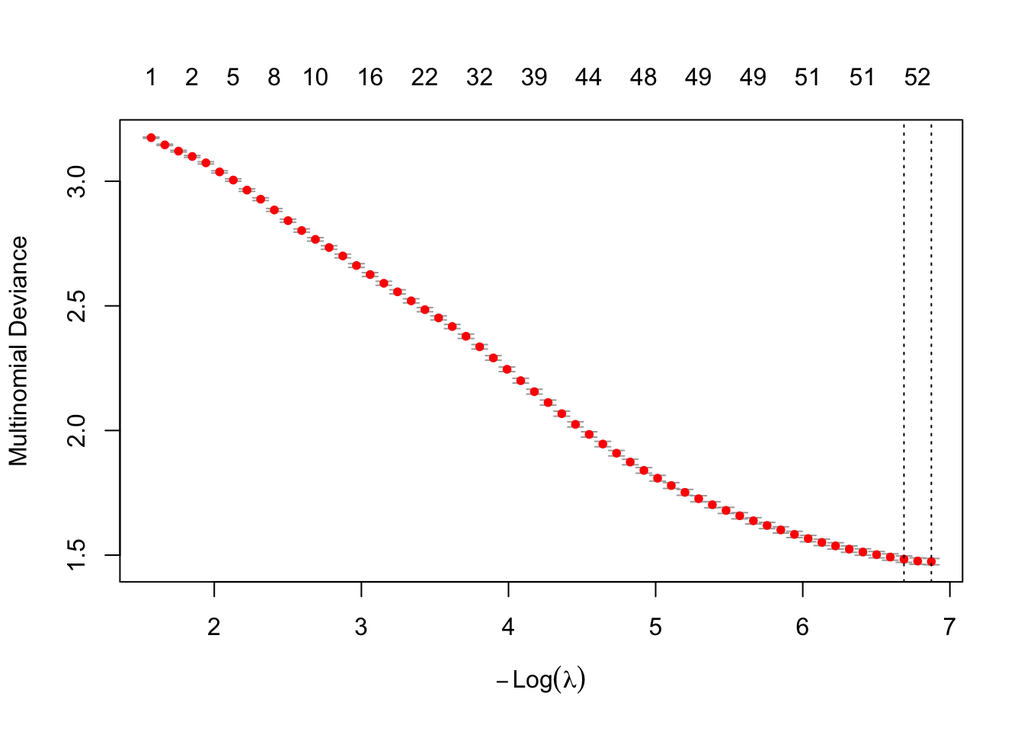

```r
coef_lassomin <- coef(cv_fit, s = "lambda.min")
plot(cv_fit)
```

Extracting selected predictors

```r
selected <- unique(unlist(lapply(coef_lassomin, function(x) {rownames(x)[x[,1] != 0]})))
```

Removing Intercept and checking selected pedictors

```r
selected <- selected[selected != "(Intercept)"]
selected
```

```
##  [1] "roll_belt"            "pitch_belt"           "yaw_belt"
##  [4] "total_accel_belt"     "gyros_belt_x"         "gyros_belt_y"
##  [7] "gyros_belt_z"         "accel_belt_x"         "accel_belt_y"
## [10] "accel_belt_z"         "magnet_belt_x"        "magnet_belt_y"
## [13] "magnet_belt_z"        "roll_arm"             "pitch_arm"
## [16] "yaw_arm"              "total_accel_arm"      "gyros_arm_x"
## [19] "gyros_arm_y"          "gyros_arm_z"          "accel_arm_x"
## [22] "accel_arm_y"          "accel_arm_z"          "magnet_arm_x"
## [25] "magnet_arm_y"         "magnet_arm_z"         "roll_dumbbell"
## [28] "pitch_dumbbell"       "yaw_dumbbell"         "total_accel_dumbbell"
## [31] "gyros_dumbbell_x"     "gyros_dumbbell_y"     "accel_dumbbell_x"
## [34] "accel_dumbbell_y"     "accel_dumbbell_z"     "magnet_dumbbell_x"
## [37] "magnet_dumbbell_y"    "magnet_dumbbell_z"    "roll_forearm"
## [40] "pitch_forearm"        "yaw_forearm"          "total_accel_forearm"
## [43] "gyros_forearm_x"      "gyros_forearm_y"      "gyros_forearm_z"
## [46] "accel_forearm_x"      "accel_forearm_y"      "accel_forearm_z"
## [49] "magnet_forearm_x"     "magnet_forearm_y"     "magnet_forearm_z"
```

Too many predictors included. Trying lambda.1se to avoid overfitting.

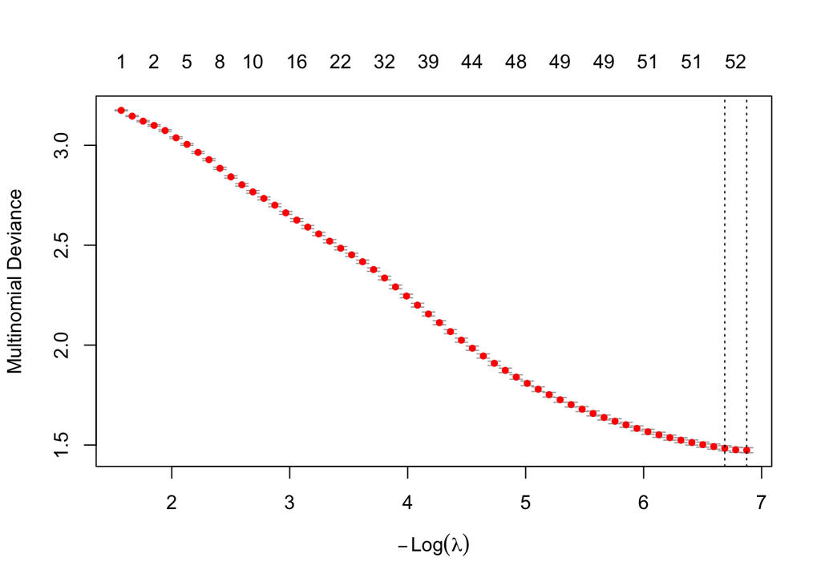

```r
coef_lasso1se <- coef(cv_fit, s = "lambda.1se")
plot(cv_fit)
```

```r
selected <- unique(unlist(lapply(coef_lasso1se, function(x) {rownames(x)[x[,1] != 0]})))
selected <- selected[selected != "(Intercept)"]
selected
```

```
##  [1] "roll_belt"            "pitch_belt"           "yaw_belt"
##  [4] "total_accel_belt"     "gyros_belt_x"         "gyros_belt_y"
##  [7] "gyros_belt_z"         "accel_belt_x"         "accel_belt_y"
## [10] "accel_belt_z"         "magnet_belt_x"        "magnet_belt_y"
## [13] "magnet_belt_z"        "roll_arm"             "pitch_arm"
## [16] "yaw_arm"              "total_accel_arm"      "gyros_arm_x"
## [19] "gyros_arm_y"          "gyros_arm_z"          "accel_arm_x"
## [22] "accel_arm_y"          "accel_arm_z"          "magnet_arm_x"
## [25] "magnet_arm_y"         "magnet_arm_z"         "roll_dumbbell"
## [28] "pitch_dumbbell"       "yaw_dumbbell"         "total_accel_dumbbell"
## [31] "gyros_dumbbell_x"     "gyros_dumbbell_y"     "accel_dumbbell_x"
## [34] "accel_dumbbell_y"     "accel_dumbbell_z"     "magnet_dumbbell_x"
## [37] "magnet_dumbbell_y"    "magnet_dumbbell_z"    "roll_forearm"
## [40] "pitch_forearm"        "yaw_forearm"          "total_accel_forearm"
## [43] "gyros_forearm_x"      "gyros_forearm_y"      "gyros_forearm_z"
## [46] "accel_forearm_x"      "accel_forearm_y"      "accel_forearm_z"
## [49] "magnet_forearm_x"     "magnet_forearm_y"     "magnet_forearm_z"
```

Still too many predictors included. Forcing to reduce the number of predictors by adjusting lambda.

```r
coef_lasso50 <- coef(cv_fit, s = cv_fit$lambda.1se * 50)
selected <- unique(unlist(lapply(coef_lasso50, function(x) {rownames(x)[x[,1] != 0]})))
selected <- selected[selected != "(Intercept)"]
selected
```

```
##  [1] "magnet_belt_y"       "magnet_arm_x"        "magnet_arm_z"
##  [4] "roll_dumbbell"       "pitch_dumbbell"      "accel_dumbbell_x"
##  [7] "magnet_dumbbell_z"   "roll_forearm"        "pitch_forearm"
## [10] "total_accel_forearm"
```

Ten predictors were selected. Checking their prediction power using cross validation.

```r
x_train_selected <- x_train[ , selected, drop = FALSE]
modRF <- train(x = x_train_selected, y = y_train, method="rf", trControl = trainControl(method = "cv", number = 5))
modRF$results
```

```
##   mtry  Accuracy     Kappa  AccuracySD     KappaSD
## 1    2 0.9407515 0.9250043 0.004847108 0.006130252
## 2    6 0.9389852 0.9227789 0.005262043 0.006661560
## 3   10 0.9276397 0.9084232 0.006730256 0.008515470
```

Accuracy is good enough but we’ll try improving it by including a few additional predictors, while limiting the number of predictors to avoid overfitting.

```r
coef_lasso40 <- coef(cv_fit, s = cv_fit$lambda.1se * 40)
selected <- unique(unlist(lapply(coef_lasso40, function(x) {rownames(x)[x[,1] != 0]})))
selected <- selected[selected != "(Intercept)"]
selected
```

```
##  [1] "magnet_belt_y"        "magnet_arm_x"         "magnet_arm_z"
##  [4] "roll_dumbbell"        "pitch_dumbbell"       "yaw_dumbbell"
##  [7] "total_accel_dumbbell" "accel_dumbbell_x"     "magnet_dumbbell_z"
## [10] "roll_forearm"         "pitch_forearm"        "total_accel_forearm"
## [13] "accel_forearm_x"      "accel_forearm_y"      "magnet_forearm_y"
```

15 predictors were selected. Checking their prediction power.

```r
x_train_selected <- x_train[ , selected, drop = FALSE]
modRF <- train(x = x_train_selected, y = y_train, method="rf", trControl = trainControl(method = "cv", number = 5))
modRF$results
```

```
##   mtry  Accuracy     Kappa  AccuracySD     KappaSD
## 1    2 0.9558364 0.9440808 0.006200916 0.007850569
## 2    8 0.9562440 0.9446167 0.007588758 0.009604309
## 3   15 0.9404121 0.9245740 0.009045701 0.011432801
```

Predictive power has not improved significantly. Fitting the initial model to the testing dataset.

```r
selected <- unique(unlist(lapply(coef_lasso50, function(x) {rownames(x)[x[,1] != 0]})))
selected <- selected[selected != "(Intercept)"]
x_train_selected <- x_train[ , selected, drop = FALSE]
modRF <- train(x = x_train_selected, y = y_train, method="rf")
predRF <- predict(modRF, x_test)
confusionMatrix(y_test, predRF)
```

```
## Confusion Matrix and Statistics
##
##           Reference
## Prediction    A    B    C    D    E
##          A 1368    6    7    9    5
##          B   32  863   35   13    6
##          C    4   13  821   15    2
##          D    8    4   30  762    0
##          E    5   13   11   16  856
##
## Overall Statistics
##
##                Accuracy : 0.9523
##                  95% CI : (0.9459, 0.9581)
##     No Information Rate : 0.2889
##     P-Value [Acc > NIR] : < 2.2e-16
##
##                   Kappa : 0.9396
##
##  Mcnemar's Test P-Value : 8.469e-10
##
## Statistics by Class:
##
##                      Class: A Class: B Class: C Class: D Class: E
## Sensitivity            0.9654   0.9600   0.9082   0.9350   0.9850
## Specificity            0.9923   0.9785   0.9915   0.9897   0.9888
## Pos Pred Value         0.9806   0.9094   0.9602   0.9478   0.9501
## Neg Pred Value         0.9860   0.9909   0.9795   0.9871   0.9968
## Prevalence             0.2889   0.1833   0.1843   0.1662   0.1772
## Detection Rate         0.2790   0.1760   0.1674   0.1554   0.1746
## Detection Prevalence   0.2845   0.1935   0.1743   0.1639   0.1837
## Balanced Accuracy      0.9788   0.9692   0.9498   0.9623   0.9869
```

In addition, several models have been checked. RF provided the best prediction power. Stacking models did not improve accuracy. Therefore, RF model has been used for this prediction.

Using the RF model to predict 20 different test cases.

```r
predRF_final <- predict(modRF, testing)
predRF_final
```

```
##  [1] B A B A A E D B A A B C B A E E A B B B
## Levels: A B C D E
```